# The relationship between long-term exposure to PM2.5 and hypertension in women：A meta-analysis - ScienceDirect

## Outline

1. Highlights
2. Abstract
3. Keywords
4. 1. Introduction
5. 2. Materials and methods
6. 3. Results
7. 4. Discussion
8. 5. Conclusion
9. Declaration of Competing Interest
10. Acknowledgements
11. Appendix A. Supplementary material
12. References

## Figures (6)

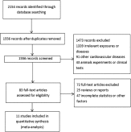

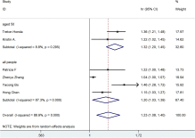

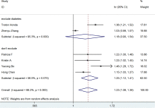

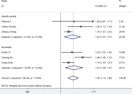

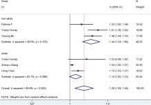

## Extras (1)

1. Supplementary material.

## [Ecotoxicology and Environmental Safety](https://www.sciencedirect.com/science/journal/01476513)

[Volume 208](https://www.sciencedirect.com/science/journal/01476513/208/supp/C), 15 January 2021, 111492

# Review The relationship between long-term exposure to PM<sub>2.5</sub> and hypertension in women：A meta-analysis

[YuexiaoMa<sup>a</sup><sup>b</sup>](https://www.sciencedirect.com/science/article/pii/S0147651320313294#!)[MengqiSun<sup>a</sup><sup>b</sup>](https://www.sciencedirect.com/science/article/pii/S0147651320313294#!)[QingqingLiang<sup>a</sup><sup>b</sup>](https://www.sciencedirect.com/science/article/pii/S0147651320313294#!)[FenghongWang<sup>a</sup><sup>b</sup>](https://www.sciencedirect.com/science/article/pii/S0147651320313294#!)[LisenLin<sup>a</sup><sup>b</sup>](https://www.sciencedirect.com/science/article/pii/S0147651320313294#!)[TianyuLi<sup>a</sup><sup>b</sup>](https://www.sciencedirect.com/science/article/pii/S0147651320313294#!)[JunchaoDuan<sup>a</sup><sup>b</sup>](https://www.sciencedirect.com/science/article/pii/S0147651320313294#!)[ZhiweiSun<sup>a</sup><sup>b</sup>](https://www.sciencedirect.com/science/article/pii/S0147651320313294#!)

https://doi.org/10.1016/j.ecoenv.2020.111492[Get rights and content](https://s100.copyright.com/AppDispatchServlet?publisherName=ELS&contentID=S0147651320313294&orderBeanReset=true)

Under a Creative Commons [license](https://creativecommons.org/licenses/by-nc-nd/4.0/)

open access

## Highlights

**•**

Long-term exposure to PM<sub>2.5</sub> is associated with the risk of hypertension in non-pregnancy women.

**•**

10 μg/m<sup>3</sup> elevation of PM<sub>2.5</sub> increases the hypertension risk with the OR of 1.07 and HR of 1.23.

## Abstract

### Objective

Gender difference and PM<sub>2.5</sub> exposure all have effects on hypertension, change of estrogen level in different women’s stage bring complex influence on blood pressure. Then we conduct this meta-analysis to investigate the association between long-term exposure (at least one year) to fine particulate matter (PM<sub>2.5</sub>) and hypertension in adult non-pregnant women.

### Method

Four major databases: PubMed, Cochrane Library, Web of Science and Embase were searched with specific search terms, and 11 studies were finally selected. The meta-analysis module of software Stata 12.0 was used for data processing with the effect values hazard ratio (HR) and odds ratio (OR) respectively.

### Results

After sensitivity analysis, we removed a study with highly heterogeneity and finally included 10 studies. Meta-analysis results showed that exposure to PM<sub>2.5</sub> (per 10 μg/m<sup>3</sup> increase) was associated with hypertension in non-pregnancy adult women, HR = 1.23, 95%CI: 1.08-1.40; OR = 1.07, 95%CI: 1.00–1.14. And subgroup analysis showed that menopause, non-White and diabetes are the key risk factors of hypertension when exposed to PM<sub>2.5</sub>.

### Conclusion

This is the first meta-analysis to explore the association between PM<sub>2.5</sub> and non-pregnancy women, and calculate OR and HR respectively for the first time. Exposure to PM<sub>2.5</sub> could increase the risk of hypertension in non-pregnancy women, and the combined ‘HR’ was much higher than ‘OR’.

## Keywords

PM<sub>2.5</sub>

Long-term exposure

Hypertension

Non-pregnancy women

## 1. Introduction

Up to now, the air pollution had been an important risk of the cardiovascular diseases. In 2015, all forms of pollution combined were responsible for 21% of all deaths from cardiovascular disease (Landrigan et al., 2018). The fine particulate matter (PM<sub>2.5</sub>) has been one of the most harmful of air pollutants. An elevation of 10 μg/m<sup>3</sup> was associated with increases of 0.55% (95%CI: 0.45–0.66) in daily cardiovascular mortality (Liu et al., 2019). Among the causes of death from cardiovascular disease, usual blood pressure is a directly and strongly factor (Lewington et al., 2002). The diagnostic criteria for hypertension is systolic blood pressure ≥ 140 mmHg and diastolic blood pressure ≥90 mmHg (Mills et al., 2020). Excessive pressure can harden arteries, decreasing the flow of blood and oxygen to the heart, finally causes serious damage to heart. And then this elevated pressure and reduced blood flow can cause arrhythmia, angina, and heart failure which can lead to a sudden death.

Exposure to PM<sub>2.5</sub>, both in short-term and long-term, has an effect on blood pressure. A review contained 4 meta-analysis reported that exposure to ambient PM<sub>2.5</sub> (10 μg/m<sup>3</sup> increase) is consistently associated with 1–3 mm Hg elevations in systolic and diastolic blood pressure over the ensuing few days (Rajagopalan et al., 2018). Long-term exposure to PM<sub>2.5</sub> shows a stronger associations with blood pressure and increases prevalence or incidence of hypertension (Liang et al., 2014). Besides, PM<sub>2.5</sub> could exacerbate the risk factors of hypertension, including obesity, diabetes (Xie et al., 2018). Except some diseases, biological factors - such as age and gender - also have differences in hypertension when exposure to PM<sub>2.5</sub>. The youth have higher risk than the elderly (Bo et al., 2019). However, the conclusions of gender differences in the impact of PM<sub>2.5</sub> on hypertension are undefined.

The results are inconsistent of studies which describe the gender differences of hypertension exposure to PM<sub>2.5</sub>. Some studies showed a higher influence of PM<sub>2.5</sub> in men (Yang et al., 2018; Li et al., 2020), while other studies reported higher influence in women (Lin et al., 2017, Zhang et al., 2018, Wu et al., 2019). The morbidity and mortality of hypertension have gender difference, women have lower morbidity and mortality in hypertension than men in reproductive age (Pilote et al., 2007), but have higher morbidity in postmenopausal than age-matched men (Benjamin et al., 2017). The US National Institutes of Health mandated that applications for funding needed to take into consideration sex as a biological variable. Hence, more studies are required to understand sex differences in hypertension and associated cardiovascular disease (Colafella and Denton, 2018).

However, there still lacks systematic reviews to detect the relationship between exposure to PM<sub>2.5</sub> and hypertension in women. Thus, we conduct this first meta-analysis to evaluate the relationship between exposure to PM<sub>2.5</sub> and hypertension in women only, and assess the effect of influence factors mentioned above on hypertension.

## 2. Materials and methods

### 2.1. Search methods

We searched the relevant articles in four databases up until 20 November, 2019: (1) PubMed, (2) Web of Science, (3) Cochrane Library and (4) Embase. And the search terms we used are the following:

#1: (adult) or (female) or (women).

#2: (PM<sub>2.5</sub>) or (fine particulate matter) or (air pollution) or (air pollutants) or (particulate matter).

#3: (hypertension) or (high blood pressure) or (blood pressure).

#4: #1 And #2 And #3.

### 2.2. Study selected and data extraction

There were two assessors screened the title and abstract of the selected studies independently. The studies were selected by the inclusion and exclusion criteria. The inclusion criteria were: 1) Articles reporting the association of PM<sub>2.5</sub> and hypertension; 2) The full text of the literature is available; 3) The studies were designed as the cross-sectional study, cohort study and case-control study; 4) All the required data of women are available; 5) Choose the largest sample or the recent study if multiple studies from the same population. And the articles were excluded if they: 1) Uncorrelated with the investigate topic; 2) Included the pregnant women and younger than 18; 3) Unavailable to extracted the required data of women; 4) Were reviews, meta-analysis, conference reports, clinical testing and animal experiments, etc; 5) Reported other air pollutants or did not contain the data of PM<sub>2.5</sub>. Each assessor extracted the information independently from the selected studies, and searched the reference articles to confirm all the studies had been included.

### 2.3. Quality assessment

Quality of these studies was evaluated by two assessors independently using the Newcastle Ottawa Scale (NOS) standard. And the studies which scored more than seven were considered the highly quality literature.

### 2.4. Statistical methods

We used the meta-analysis module of software Stata 12.0 for data processing. The OR value or the HR value of hypertension outcome were taken as the effect value. Firstly we normalized the exposure values’ increasing unit as 10 μg/m<sup>3.</sup> Considering the effect value ‘HR’ including time factors, we calculated the effect values ‘HR’ and ‘OR’ separately. Then we used heterogeneity test to detect the heterogeneity of these articles, if *p* < 0.05, it indicated there was a greater heterogeneity in these articles, and the random-effect model should be used to calculate the combined value, or else the fixed-effect model was chosen. Subgroup analysis was performed based on possible confounding factors to confirm the source of heterogeneity from these articles. The total of studies less than ten when the effect values HR and OR calculated respectively, and according to the Cochrane hand book, the test for publication bias such as Egger’s method is not advised to use in this meta-analysis. Sensitivity analysis was used to evaluate the impact of potential labile factors in meta-analysis on overall results.

## 3. Results

### 3.1. Study search and characteristics

At least we included 2154 studies, and 1556 studies were remained after removing the duplicates. And after reading the titles and abstracts of these studies, we excluded 1339 studies described irrelevant air pollutants or other system diseases. Then, 91 studies which did not mention hypertension and 43 studies which were clinical tests or animals experiments or other non-epidemiological studies were excluded. We reviewed the full texts of the remaining 83 studies and eliminated 25 reviews or conference reports. 40 studies were excluded for unavailable to get the required data. And there were 7 articles used the same population or contained other studies’ population, so we chose 3 studies with the largest population. Finally we included 11 articles in our meta-analysis (Miller et al., 2007, Johnson and Parker, 2009, Chen et al., 2014, Chan et al., 2015, Coogan et al., 2016, Zhang et al., 2016, Honda et al., 2017, Lin et al., 2017, Liu et al., 2017, Wu et al., 2019) (Fig. 1).

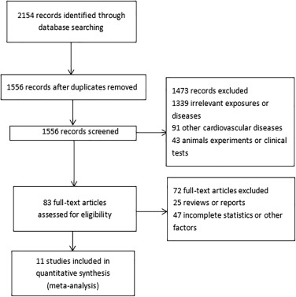

1. [Download : Download high-res image (224KB)](https://ars.els-cdn.com/content/image/1-s2.0-S0147651320313294-gr1_lrg.jpg)
2. [Download : Download full-size image](https://ars.els-cdn.com/content/image/1-s2.0-S0147651320313294-gr1.jpg)

Fig. 1. The flow chart of literature retrieval.

The characteristics of these articles were displayed in Table S1. In these 11 studies, there were 7 cohort studies and other 4 studies were cross-sectional studies. The sample size ranged from 6755 to 298,383. In terms of research areas, 4 studies from China, 4 studies from America and 3 from the institution. Four studies’ period continued more than 10 years. Based on NOS score, there are seven studies (63.6%) scored ≥ 7 and considered as high-quality documents in eleven studies.

Most of these eleven studies confirmed the association between PM<sub>2.5</sub> exposure and hypertension in women. Five studies (Johnson and Parker, 2009, Chan et al., 2015, Lin et al., 2017, Liu et al., 2017, Wu et al., 2019) used OR as effect value while 6 studies (Miller et al., 2007, Chen et al., 2014, Coogan et al., 2016, Zhang et al., 2016, Honda et al., 2017) used HR. We calculated the relationship between PM<sub>2.5</sub> and hypertension in women used the effect values HR and OR respectively (Hutton et al., 2015).

### 3.2. Relationship between PM<sub>2.5</sub> and hypertension in women

After sensitivity analysis, we removed one study with highly heterogeneity (Wu et al., 2019). A total of four studies which used OR as effect values combined to analyze the association between PM<sub>2.5</sub> and women hypertension. The heterogeneity test showed the I<sup>2</sup> = 68.9%, *p* < 0.05, indicated a large amount of heterogeneity among these studies, so we adopted the random-effect model and forest plot is the Fig. 2A. The result showed that with the increasing of the PM<sub>2.5</sub> (10 μg/m<sup>3</sup>), the rates of hypertension in women changed, as the OR was 1.07 (95%CI: 1.00–1.14), suggesting a weak association between PM<sub>2.5</sub> and hypertension in women.

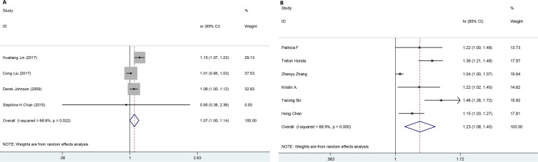

1. [Download : Download high-res image (328KB)](https://ars.els-cdn.com/content/image/1-s2.0-S0147651320313294-gr2_lrg.jpg)
2. [Download : Download full-size image](https://ars.els-cdn.com/content/image/1-s2.0-S0147651320313294-gr2.jpg)

Fig. 2. Forest plot of PM<sub>2.5</sub> exposure and hypertension in women (A) used OR effect value (B) used HR effect value.

Six of these studies used HR as the effect values and were combined to analyze the relationship between PM<sub>2.5</sub> and hypertension in female. The heterogeneity test showed highly heterogeneity (I<sup>2</sup> = 88.9%, *p* < 0.001), and the result indicated that with 10 μg/m<sup>3</sup> increase in concentration, the risk of hypertension in women had been changed. The HR was 1.23 (95%CI: 1.08–1.40), illustrated that exposure to PM<sub>2.5</sub> was associated with hypertension in non-pregnancy adult women. The forest plot is showed in Fig. 2B.

### 3.3. Subgroup analysis

We classified postmenopausal as women aged 50 according to the criteria of the Women's Health Initiative (Colafella and Denton, 2018). Two studies based on women aged 50, and the results showed that exposure to PM<sub>2.5</sub> was strongly correlated to hypertension in women in the group of aged 50 (HR = 1.32, 95%CI: 1.20–1.45) (Fig. 3). And there were two studies contained the HR of which excluded the diabetes population and the result (Fig. 4) showed that the risk of hypertension in women decreased when excluded the diabetes, HR = 1.18, 95%CI: 0.90–1.54. Three studies calculated the relationship between PM<sub>2.5</sub> and women hypertension in obesity (BMI > 30) people separately while other three studies didn’t. Subgroup analysis showed obese people didn’t have highly risk of hypertension when exposure to PM<sub>2.5</sub> (HR = 1.23, 95%CI: 1.07–1.41 vs HR = 1.27, 95%CI: 1.09–1.47) (Fig. 5). Among the 6 studies used the HR as the effect values, there were two groups divided by race: white and non-white. The results (Fig. 6) showed, when exposed to PM<sub>2.5</sub> (per 10 μg/m<sup>3</sup> increase), the risk of hypertension was highly in non-White women (HR = 1.44, 95%CI: 1.24–1.66).

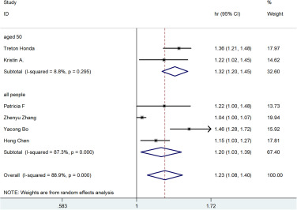

1. [Download : Download high-res image (312KB)](https://ars.els-cdn.com/content/image/1-s2.0-S0147651320313294-gr3_lrg.jpg)
2. [Download : Download full-size image](https://ars.els-cdn.com/content/image/1-s2.0-S0147651320313294-gr3.jpg)

Fig. 3. Subgroup analysis aged 50 women and all age women.

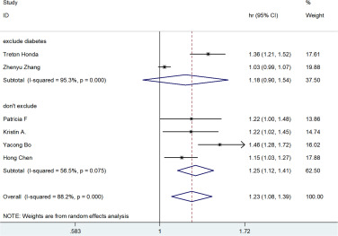

1. [Download : Download high-res image (306KB)](https://ars.els-cdn.com/content/image/1-s2.0-S0147651320313294-gr4_lrg.jpg)
2. [Download : Download full-size image](https://ars.els-cdn.com/content/image/1-s2.0-S0147651320313294-gr4.jpg)

Fig. 4. Subgroup analysis of whether study excluded women with diabetes or not.

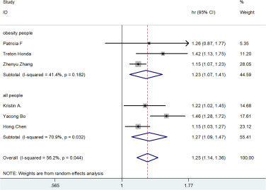

1. [Download : Download high-res image (313KB)](https://ars.els-cdn.com/content/image/1-s2.0-S0147651320313294-gr5_lrg.jpg)
2. [Download : Download full-size image](https://ars.els-cdn.com/content/image/1-s2.0-S0147651320313294-gr5.jpg)

Fig. 5. Subgroup analysis of obese women and non-obese women.

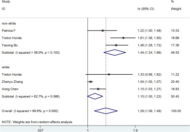

1. [Download : Download high-res image (308KB)](https://ars.els-cdn.com/content/image/1-s2.0-S0147651320313294-gr6_lrg.jpg)
2. [Download : Download full-size image](https://ars.els-cdn.com/content/image/1-s2.0-S0147651320313294-gr6.jpg)

Fig. 6. Subgroup analysis of non-white women and white women.

### 3.4. Sensitivity analyses

We performed sensitivity analysis by using the one-by-one elimination method, random-effect model was used due to great heterogeneity in these studies. The studies with effect value ‘HR’ and ‘OR’ were tested respectively. And the result showed that the pooled HR value and 95% CI were not significantly changed before and after excluding a certain study. But a study from effect value of ‘OR’ showed a highly heterogeneity (Wu et al., 2019) (Fig. S1). Then we removed this study and combined the other four studies.

## 4. Discussion

PM<sub>2.5</sub> could induce vascular endothelial dysfunction and vascular constriction impairment, finally lead to hypertension and cardiovascular diseases (Giorgini et al., 2016). Sex hormones and sex chromosomes are the influence factors of blood pressure and the cardiovascular diseases across the course of life (Colafella and Denton, 2018). And increasing evidences show that findings of studies in males do not always appropriate to females. There has been confirmed that PM<sub>2.5</sub> exposure would increase the risk of hypertensive disorder in pregnancy (Sun et al., 2020). However, pregnancy is a short special period of women, the influence of PM<sub>2.5</sub> exposure on hypertension in non-pregnancy is unconfirmed. In this meta-analysis, we investigated the relationship between PM<sub>2.5</sub> exposure and hypertension in non-pregnancy adult women, and evaluated the effect of risk factors in subgroups analysis.

We searched four databases, and removed one study (Wu et al., 2019) with highly heterogeneity and finally included 10 studies. Considered the difference effect values in these studies, we calculated HR and OR respectively. Results showed that exposure to the PM<sub>2.5</sub> had relationship with the hypertension in women, both in OR (Fig. 2A) and HR (Fig. 2B). And we could also find the same conclusion in other meta-analysis, which detected the relationship between air pollution and hypertension among female and men. A meta-analysis in 2016 showed a week association of hypertension and 10 μg/m<sup>3</sup> increment in long-term exposure to PM<sub>2.5</sub> (OR = 1.065, 95%CI: 0.985–1.152) (Cai et al., 2016). Closely to this study, the OR in our research is 1.07. Another meta-analysis pooled HR and OR together (Yang et al., 2018), the combined OR is 1.05 (95%CI: 1.01–1.09). To our knowledge, this is the first meta-analysis calculated the OR and HR respectively to detect the relationship between PM<sub>2.5</sub> and hypertension. In our study, the HR was 1.23 (95%CI: 1.08–1.40), higher than OR. When combined HR and OR together, it might have underestimated the pro-hypertensive effects of air pollutants (Yang et al., 2018), and it might be the reason of the difference between OR and HR in our research.

We divided group according to the known risk factors of hypertension to conduct the subgroup analysis. We calculated the studies used HR as value effect to make subgroup analysis for the lack of studies with OR. In this study, we found menopause women are more susceptible in hypertension when exposure to PM<sub>2.5</sub> (Fig. 3). Serum estradiol (E<sub>2</sub>) is the most potent estrogen in humans, which will potentially lower blood pressure as a vasodilator (Wang et al., 2012). However, E<sub>2</sub> may also induce insulin resistance and thereafter tend to raise blood pressure, and the association is significantly in postmenopausal women (Wang et al., 2012). Thus, although premenopausal women have a lower incidence and severity of hypertension than men, the risk increases sharply after menopause. In a 2017 study which conduct the influence of hypertension in elder people exposure to PM<sub>2.5</sub>, the risk of women was higher than men, the OR is 1.15 while the OR is 1.13 in men (Lin et al., 2017). Although E<sub>2</sub> has the function of lowering blood pressure, this production would disappear in obesity or diabetes (Colafella and Denton, 2018). In our study, we found that women combined diabetes (Fig. 4) had highly risk of hypertension when exposed to PM<sub>2.5</sub>. However, obesity didn’t increase risk of hypertension related with PM<sub>2.5</sub> in our study (Fig. 5) compared with other study (Mazidi and Speakman, 2018), might be due to small amount of studies we included. Obesity substantially increases the risk of hypertension had become a consensus as reported (Seravalle and Grassi, 2017), advised that obesity should be considered as an independent risk factor in future studies. In our meta-analysis, we found that exposure to PM<sub>2.5</sub> have more effect on non-White people and the difference was significant statistically (Fig. 6). Yet a report showed that exposure to PM<sub>2.5</sub> did not have statistical difference of hypertension in different races although it has the lowest influence on White women (Song et al., 2020). The reason for the difference might be that in our meta-analysis, we used only 6 studies to make subgroup analysis and we combined Black and Asian in the non-white group. And our study did not contain all the races, we need more relative studies to confirm our conclusion.

The heterogeneity in this meta-analysis maybe come from the study design, study choose and the definition of study results. Most of the studies we selected were retrospective studies and caused the recall bias. And we calculate the effect values HR and OR respectively, thus each group had fewer than 10 studies. The area from the most studies is America and China, and regional limitations may be the source of heterogeneity, resulting in selection bias. Besides, the judgement of hypertension diagnosis is different, some come from the hospital’s data and some from the questionnaire and leading to information bias. The sensitivity analysis showed one study with highly heterogeneity (Wu et al., 2019). This study was designed to reflect the influence of spatial distribution of PM<sub>2.5</sub> on hypertension and used the shared component model, for the possible reason of heterogeneity. Besides, although some hypertension risk factors such as smoke, alcohol, education, family income had been adjusted in included studies, other possible factors of hypertension had been ignored. For example, the ignore of the use of estrogen and progesterone (contraceptive and hormone replace therapy) (Curtis et al., 2006, Manson et al., 2017) and the illness history with polycystic ovary syndrome (PCOS) (Ng et al., 2019) are also the composition of information bias.

## Declaration of Competing Interest

The authors declare that they have no known competing financial interests or personal relationships that could have appeared to influence the work reported in this paper.

## Acknowledgements

This work was supported by National Key Research and Development Program of China (2017YFC0211600, 2017YFC0211602, 2017YFC0211606), National Natural Science Foundation of China (91943301).

## Appendix A. Supplementary material

[Download : Download Acrobat PDF file (503KB)](https://ars.els-cdn.com/content/image/1-s2.0-S0147651320313294-mmc1.pdf)

Supplementary material.

.

## References

**Benjamin et al., 2017**

E.J. Benjamin, M.J. Blaha, S.E. Chiuve, M. Cushman, S.R. Das, R. Deo, S.D. de Ferranti, J. Floyd, M. Fornage, C. Gillespie, C.R. Isasi, M.C. Jiménez, L.C. Jordan, S.E. Judd, D. Lackland, J.H. Lichtman, L. Lisabeth, S. Liu, C.T. Longenecker, R.H. Mackey, K. Matsushita, D. Mozaffarian, M.E. Mussolino, K. Nasir, R.W. Neumar, L. Palaniappan, D.K. Pandey, R.R. Thiagarajan, M.J. Reeves, M. Ritchey, C.J. Rodriguez, G.A. Roth, W.D. Rosamond, C. Sasson, A. Towfighi, C.W. Tsao, M.B. Turner, S.S. Virani, J.H. Voeks, J.Z. Willey, J.T. Wilkins, J.H. Wu, H.M. Alger, S.S. Wong, P. Muntner**Heart disease and stroke statistics-2017 update: a report from the american heart association**

Circulation, 135 (10) (2017), pp. e146-e603

[CrossRef](https://doi.org/10.1161/CIR.0000000000000485)[View Record in Scopus](https://www.scopus.com/inward/record.url?eid=2-s2.0-85019762019&partnerID=10&rel=R3.0.0)Google Scholar

**Bo et al., 2019**

Y. Bo, C. Guo, C. Lin, L. Chang, T.C. Chan, B. Huang, K.P. Lee, T. Tam, A.K.H. Lau, X.Q. Lao, E.K. Yeoh**Dynamic changes in long-term exposure to ambient particulate matter and incidence of hypertension in adults**

Hypertension, 74 (3) (2019), pp. 669-677

[CrossRef](https://doi.org/10.1161/hypertensionaha.119.13212)[View Record in Scopus](https://www.scopus.com/inward/record.url?eid=2-s2.0-85071347650&partnerID=10&rel=R3.0.0)Google Scholar

**Cai et al., 2016**

Y. Cai, B. Zhang, W. Ke, B. Feng, H. Lin, J. Xiao, W. Zeng, X. Li, J. Tao, Z. Yang, W. Ma, T. Liu**Associations of short-term and long-term exposure to ambient air pollutants with hypertension: a systematic review and meta-analysis**

Hypertension, 68 (1) (2016), pp. 62-70

[View Record in Scopus](https://www.scopus.com/inward/record.url?eid=2-s2.0-84973308355&partnerID=10&rel=R3.0.0)Google Scholar

**Chan et al., 2015**

S.H. Chan, V.C. Van Hee, S. Bergen, A.A. Szpiro, L.A. DeRoo, S.J. London, J.D. Marshall, J.D. Kaufman, D.P. Sandler**Long-term air pollution exposure and blood pressure in the sister study**

Environ. Health Perspect., 123 (10) (2015), pp. 951-958

(Oct)

[View Record in Scopus](https://www.scopus.com/inward/record.url?eid=2-s2.0-84941781315&partnerID=10&rel=R3.0.0)Google Scholar

**Chen et al., 2014**

H. Chen, R.T. Burnett, J.C. Kwong, P.J. Villeneuve, M.S. Goldberg, R.D. Brook, A. van Donkelaar, M. Jerrett, R.V. Martin, A. Kopp, J.R. Brook, R. Copes**Spatial association between ambient fine particulate matter and incident hypertension**

Circulation, 129 (5) (2014), pp. 562-569

[View Record in Scopus](https://www.scopus.com/inward/record.url?eid=2-s2.0-84895069692&partnerID=10&rel=R3.0.0)Google Scholar

**Colafella and Denton, 2018**

K.M.M. Colafella, K.M. Denton**Sex-specific differences in hypertension and associated cardiovascular disease**

Nat. Rev. Nephrol., 14 (3) (2018), pp. 185-201

[CrossRef](https://doi.org/10.1038/nrneph.2017.189)[View Record in Scopus](https://www.scopus.com/inward/record.url?eid=2-s2.0-85044187418&partnerID=10&rel=R3.0.0)Google Scholar

**Coogan et al., 2016**

P.F. Coogan, L.F. White, J. Yu, R.T. Burnett, E. Seto, R.D. Brook, *et al.***PM2.5 and diabetes and hypertension incidence in the black women’s health study**

Epidemiology, 27 (2) (2016), pp. 202-210

[View Record in Scopus](https://www.scopus.com/inward/record.url?eid=2-s2.0-84957435889&partnerID=10&rel=R3.0.0)[Google Scholar](https://scholar.google.com/scholar?q=PM2.5%20and%20diabetes%20and%20hypertension%20incidence%20in%20the%20black%20womens%20health%20study)

**Curtis et al., 2006**

K.M. Curtis, A.P. Mohllajee, S.L. Martins, H.B. Peterson**Combined oral contraceptive use among women with hypertension: a systematic review**

Contraception, 73 (2) (2006), pp. 179-188

[Article](https://www.sciencedirect.com/science/article/pii/S0010782405003136)[Download PDF](https://www.sciencedirect.com/science/article/pii/S0010782405003136/pdfft?md5=42d0484c091f3dd3670f304158654b74&pid=1-s2.0-S0010782405003136-main.pdf)[View Record in Scopus](https://www.scopus.com/inward/record.url?eid=2-s2.0-30644474019&partnerID=10&rel=R3.0.0)Google Scholar

**Giorgini et al., 2016**

P. Giorgini, P. Di Giosia, D. Grassi, M. Rubenfire, R.D. Brook, C. Ferri**Air pollution exposure and blood pressure: an updated review of the literature**

Curr. Pharm. Des., 22 (1) (2016), pp. 28-51

[View Record in Scopus](https://www.scopus.com/inward/record.url?eid=2-s2.0-84953404529&partnerID=10&rel=R3.0.0)Google Scholar

**Honda et al., 2017**

T. Honda, M.N. Eliot, C.B. Eaton, E. Whitsel, J.D. Stewart, L. Mu, H. Suh, A. Szpiro, J.D. Kaufman, S. Vedal, G.A. Wellenius**Long-term exposure to residential ambient fine and coarse particulate matter and incident hypertension in post-menopausal women**

Environ. Int., 105 (2017), pp. 79-85

[Article](https://www.sciencedirect.com/science/article/pii/S0160412017303860)[Download PDF](https://www.sciencedirect.com/science/article/pii/S0160412017303860/pdfft?md5=56b937e7d1885b767671008d9ade2c36&pid=1-s2.0-S0160412017303860-main.pdf)[View Record in Scopus](https://www.scopus.com/inward/record.url?eid=2-s2.0-85019217270&partnerID=10&rel=R3.0.0)Google Scholar

**Hutton et al., 2015**

B. Hutton, G. Salanti, D.M. Caldwell, A. Chaimani, C.H. Schmid, C. Cameron, J.P.A. Ioannidis, S. Straus, K. Thorlund, J.P. Jansen, C. Mulrow, F. Catalá-López, P.C. Gøtzsche, K. Dickersin, I. Boutron, D.G. Altman, D. Moher**The PRISMA extension statement for reporting of systematic reviews incorporating network meta-analyses of health care interventions: checklist and explanations**

Ann. Intern Med., 162 (11) (2015), pp. 777-784

[CrossRef](https://doi.org/10.7326/M14-2385)[View Record in Scopus](https://www.scopus.com/inward/record.url?eid=2-s2.0-84932084410&partnerID=10&rel=R3.0.0)Google Scholar

**Johnson and Parker, 2009**

D. Johnson, J.D. Parker**Air pollution exposure and self-reported cardiovascular disease**

Environ. Res., 109 (5) (2009), pp. 582-589

[Article](https://www.sciencedirect.com/science/article/pii/S0013935109000164)[Download PDF](https://www.sciencedirect.com/science/article/pii/S0013935109000164/pdfft?md5=d943326099c2e927ad197cee1176af7b&pid=1-s2.0-S0013935109000164-main.pdf)[View Record in Scopus](https://www.scopus.com/inward/record.url?eid=2-s2.0-67349131569&partnerID=10&rel=R3.0.0)[Google Scholar](https://scholar.google.com/scholar_lookup?title=Air%20pollution%20exposure%20and%20self-reported%20cardiovascular%20disease&publication_year=2009&author=D.%20Johnson&author=J.D.%20Parker)

**Landrigan et al., 2018**

P.J. Landrigan, R. Fuller, N.J.R. Acosta, O. Adeyi, R. Arnold, N. Basu, A.B. Baldé, R. Bertollini, S. Bose-O’Reilly, J.I. Boufford, P.N. Breysse, T. Chiles, C. Mahidol, A.M. Coll-Seck, M.L. Cropper, J. Fobil, V. Fuster, M. Greenstone, A. Haines, D. Hanrahan, D. Hunter, M. Khare, A. Krupnick, B. Lanphear, B. Lohani, K. Martin, K.V. Mathiasen, M.A. McTeer, C.J.L. Murray, J.D. Ndahimananjara, F. Perera, J. Potočnik, A.S. Preker, J. Ramesh, J. Rockström, C. Salinas, L.D. Samson, K. Sandilya, P.D. Sly, K.R. Smith, A. Steiner, R.B. Stewart, W.A. Suk, O.C.P. van Schayck, G.N. Yadama, K. Yumkella, M. Zhong**The Lancet Commission on pollution and health**

Lancet, 391 (10119) (2018), pp. 462-512

[Article](https://www.sciencedirect.com/science/article/pii/S0140673617323450)[Download PDF](https://www.sciencedirect.com/science/article/pii/S0140673617323450/pdfft?md5=acb87af84a87332c1d9910c597c1cb33&pid=1-s2.0-S0140673617323450-main.pdf)[View Record in Scopus](https://www.scopus.com/inward/record.url?eid=2-s2.0-85031763844&partnerID=10&rel=R3.0.0)Google Scholar

**Lewington et al., 2002**

S. Lewington, R. Clarke, N. Qizilbash, R. Peto, R. Collins**Age-specific relevance of usual blood pressure to vascular mortality: a meta-analysis of individual data for one million adults in 61 prospective studies**

Lancet, 360 (9349) (2002), pp. 1903-1913

[View Record in Scopus](https://www.scopus.com/inward/record.url?eid=2-s2.0-0037079309&partnerID=10&rel=R3.0.0)Google Scholar

**Liang et al., 2014**

R. Liang, B. Zhang, X. Zhao, Y. Ruan, H. Lian, Z. Fan**Effect of exposure to PM2.5 on blood pressure: a systematic review and meta-analysis**

J. Hypertens., 32 (11) (2014), pp. 2130-2140

[View Record in Scopus](https://www.scopus.com/inward/record.url?eid=2-s2.0-84925452239&partnerID=10&rel=R3.0.0)Google Scholar

**Lin et al., 2017**

H. Lin, Y. Guo, Y. Zheng, Q. Di, T. Liu, J. Xiao, X. Li, W. Zeng, L.A. Cummings-Vaughn, S.W. Howard, M.G. Vaughn, Z. Qian, W. Ma, F. Wu**Long-term effects of ambient PM2.5 on hypertension and blood pressure and attributable risk among older chinese adults**

Hypertension, 69 (5) (2017), pp. 806-812

[View Record in Scopus](https://www.scopus.com/inward/record.url?eid=2-s2.0-85016116158&partnerID=10&rel=R3.0.0)Google Scholar

**Liu et al., 2017**

C. Liu, R. Chen, Y. Zhao, Z. Ma, J. Bi, Y. Liu, X. Meng, Y. Wang, X. Chen, W. Li, H. Kan**Associations between ambient fine particulate air pollution and hypertension: a nationwide cross-sectional study in China**

Sci. Total Environ., 584–585 (2017), pp. 869-874

[Article](https://www.sciencedirect.com/science/article/pii/S0048969717301456)[Download PDF](https://www.sciencedirect.com/science/article/pii/S0048969717301456/pdfft?md5=a3aa182f425684e4b50c07bf50f7b2e6&pid=1-s2.0-S0048969717301456-main.pdf)[View Record in Scopus](https://www.scopus.com/inward/record.url?eid=2-s2.0-85027939253&partnerID=10&rel=R3.0.0)Google Scholar

**Liu et al., 2019**

C. Liu, R. Chen, F. Sera, A.M. Vicedo-Cabrera, Y. Guo, S. Tong, M.S.Z.S. Coelho, P.H.N. Saldiva, E. Lavigne, P. Matus, N. Valdes Ortega, S. Osorio Garcia, M. Pascal, M. Stafoggia, M. Scortichini, M. Hashizume, Y. Honda, M. Hurtado-Díaz, J. Cruz, B. Nunes, J.P. Teixeira, H. Kim, A. Tobias, C. Íñiguez, B. Forsberg, C. Åström, M.S. Ragettli, Y.L. Guo, B.Y. Chen, M.L. Bell, C.Y. Wright, N. Scovronick, R.M. Garland, A. Milojevic, J. Kyselý, A. Urban, H. Orru, E. Indermitte, J.J.K. Jaakkola, N.R.I. Ryti, K. Katsouyanni, A. Analitis, A. Zanobetti, J. Schwartz, J. Chen, T. Wu, A. Cohen, A. Gasparrini, H. Kan**Ambient particulate air pollution and daily mortality in 652 cities**

N. Engl. J. Med., 381 (8) (2019), pp. 705-715

[CrossRef](https://doi.org/10.1056/nejmoa1817364)[View Record in Scopus](https://www.scopus.com/inward/record.url?eid=2-s2.0-85071318200&partnerID=10&rel=R3.0.0)Google Scholar

**Manson et al., 2017**

J.E. Manson, A.K. Aragaki, J.E. Rossouw, G.L. Anderson, R.L. Prentice, A.Z. LaCroix, R.T. Chlebowski, B.V. Howard, C.A. Thomson, K.L. Margolis, C.E. Lewis, M.L. Stefanick, R.D. Jackson, K.C. Johnson, L.W. Martin, S.A. Shumaker, M.A. Espeland, J. Wactawski-Wende**Menopausal hormone therapy and long-term all-cause and cause-specific mortality: the women’s health initiative randomized trials**

Jama, 318 (10) (2017), pp. 927-938

[CrossRef](https://doi.org/10.1001/jama.2017.11217)[View Record in Scopus](https://www.scopus.com/inward/record.url?eid=2-s2.0-85029557031&partnerID=10&rel=R3.0.0)[Google Scholar](https://scholar.google.com/scholar?q=Menopausal%20hormone%20therapy%20and%20long-term%20all-cause%20and%20cause-specific%20mortality:%20the%20womens%20health%20initiative%20randomized%20trials)

**Mazidi and Speakman, 2018**

M. Mazidi, J.R. Speakman**Impact of obesity and ozone on the association between particulate air pollution and cardiovascular disease and stroke mortality among US adults**

J. Am. Heart Assoc., 7 (11) (2018), Article e008006

Google Scholar

**Miller et al., 2007**

K.A. Miller, D.S. Siscovick, L. Sheppard, K. Shepherd, J.H. Sullivan, G.L. Anderson, J.D. Kaufman**Long-term exposure to air pollution and incidence of cardiovascular events in women**

N. Engl. J. Med., 356 (5) (2007), pp. 447-458

[View Record in Scopus](https://www.scopus.com/inward/record.url?eid=2-s2.0-33846688887&partnerID=10&rel=R3.0.0)Google Scholar

**Mills et al., 2020**

K.T. Mills, A. Stefanescu, J. He**The global epidemiology of hypertension**

Nat. Rev. Nephrol., 16 (2020), pp. 223-237

[CrossRef](https://doi.org/10.1038/s41581-019-0244-2)[View Record in Scopus](https://www.scopus.com/inward/record.url?eid=2-s2.0-85079443962&partnerID=10&rel=R3.0.0)[Google Scholar](https://scholar.google.com/scholar_lookup?title=The%20global%20epidemiology%20of%20hypertension&publication_year=2020&author=K.T.%20Mills&author=A.%20Stefanescu&author=J.%20He)

**Ng et al., 2019**

N.Y.H. Ng, G. Jiang, L.P. Cheung, Y. Zhang, C.H.T. Tam, A.O.Y. Luk, J. Quan, E.S.H. Lau, T.T.L. Yau, M.H.M. Chan, C.S. Ho, C.K.P. Lim, R. Ozaki, J. Huang, K.H. Liu, W.H. Tam, D.S. Sahota, W.C.W. Chu, W. Goggins, J. Woo, T.C. Li, C.C. Chow, J.C.N. Chan, R.C.W. Ma**Progression of glucose intolerance and cardiometabolic risk factors over a decade in Chinese women with polycystic ovary syndrome: a case-control study**

PLoS Med., 16 (10) (2019), Article e1002953

[CrossRef](https://doi.org/10.1371/journal.pmed.1002953)Google Scholar

**Pilote et al., 2007**

L. Pilote, K. Dasgupta, V. Guru, K.H. Humphries, J. McGrath, C. Norris, D. Rabi, J. Tremblay, A. Alamian, T. Barnett, J. Cox, W.A. Ghali, S. Grace, P. Hamet, T. Ho, S. Kirkland, M. Lambert, D. Libersan, J. O’Loughlin, G. Paradis, M. Petrovich, V. Tagalakis**A comprehensive view of sex-specific issues related to cardiovascular disease**

Cmaj, 176 (6) (2007), pp. S1-S44

[CrossRef](https://doi.org/10.1503/cmaj.051455)Google Scholar

**Rajagopalan et al., 2018**

S. Rajagopalan, S.G. Al-Kindi, R.D. Brook**Air pollution and cardiovascular disease: JACC state-of-the-art review**

J. Am. Coll. Cardiol., 72 (17) (2018), pp. 2054-2070

[Article](https://www.sciencedirect.com/science/article/pii/S0735109718383554)[Download PDF](https://www.sciencedirect.com/science/article/pii/S0735109718383554/pdfft?md5=4189f885554b9c2dfb5c80aee0dc0daf&pid=1-s2.0-S0735109718383554-main.pdf)[View Record in Scopus](https://www.scopus.com/inward/record.url?eid=2-s2.0-85054176359&partnerID=10&rel=R3.0.0)Google Scholar

**Seravalle and Grassi, 2017**

G. Seravalle, G. Grassi**Obesity and hypertension**

Pharm. Res., 122 (2017), pp. 1-7

(Aug)

[Article](https://www.sciencedirect.com/science/article/pii/S1043661817304620)[Download PDF](https://www.sciencedirect.com/science/article/pii/S1043661817304620/pdfft?md5=6737d1c44c1aad541418cad961898983&pid=1-s2.0-S1043661817304620-main.pdf)[View Record in Scopus](https://www.scopus.com/inward/record.url?eid=2-s2.0-85019645495&partnerID=10&rel=R3.0.0)[Google Scholar](https://scholar.google.com/scholar_lookup?title=Obesity%20and%20hypertension&publication_year=2017&author=G.%20Seravalle&author=G.%20Grassi)

**Song et al., 2020**

L. Song, G.S. Smith, S.D. Adar, W.S. Post, E. Guallar, A. Navas-Acien, J.D. Kaufman, M.R. Jones**Ambient air pollution as a mediator in the pathway linking race/ethnicity to blood pressure elevation: the multi-ethnic study of atherosclerosis (MESA)**

Environ. Res., 180 (2020), Article 108776

[Article](https://www.sciencedirect.com/science/article/pii/S0013935119305730)[Download PDF](https://www.sciencedirect.com/science/article/pii/S0013935119305730/pdfft?md5=9b2c3773e9d64255ffbd537839c6328a&pid=1-s2.0-S0013935119305730-main.pdf)Google Scholar

**Sun et al., 2020**

M. Sun, W. Yan, K. Fang, D. Chen, J. Liu, Y. Chen, J. Duan, R. Chen, Z. Sun, X. Wang, Y. Xia**The correlation between PM2.5 exposure and hypertensive disorders in pregnancy: a Meta-analysis**

Sci. Total Environ., 703 (2020), Article 134985

[Article](https://www.sciencedirect.com/science/article/pii/S0048969719349770)[Download PDF](https://www.sciencedirect.com/science/article/pii/S0048969719349770/pdfft?md5=632713e19c872cdbf67df545c79fa830&pid=1-s2.0-S0048969719349770-main.pdf)Google Scholar

**Wang et al., 2012**

L. Wang, M. Szklo, A.R. Folsom, N.R. Cook, S.M. Gapstur, P. Ouyang**Endogenous sex hormones, blood pressure change, and risk of hypertension in postmenopausal women: the Multi-ethnic Study of Atherosclerosis**

Atherosclerosis, 224 (1) (2012), pp. 228-234

[Article](https://www.sciencedirect.com/science/article/pii/S0021915012004509)[Download PDF](https://www.sciencedirect.com/science/article/pii/S0021915012004509/pdfft?md5=15c17c6ea0e1bdfb8317af85610a252f&pid=1-s2.0-S0021915012004509-main.pdf)[View Record in Scopus](https://www.scopus.com/inward/record.url?eid=2-s2.0-84865384521&partnerID=10&rel=R3.0.0)Google Scholar

**Wu et al., 2019**

Y. Wu, Z. Ye, Y. Fang**Spatial analysis of the effects of PM2.5 on hypertension among the middle-aged and elderly people in China**

Int J. Environ. Health Res. (2019), pp. 1-12

[CrossRef](https://doi.org/10.1080/09603123.2019.1682528)[View Record in Scopus](https://www.scopus.com/inward/record.url?eid=2-s2.0-85064692415&partnerID=10&rel=R3.0.0)Google Scholar

**Xie et al., 2018**

X. Xie, Y. Wang, Y. Yang, J. Xu, Y. Zhang, W. Tang, T. Guo, Q. Wang, H. Shen, Y. Zhang, D. Yan, Z. Peng, Y. Chen, Y. He, X. Ma**Long-term effects of ambient particulate matter (With an aerodynamic diameter </=2.5 mum) on hypertension and blood pressure and attributable risk among reproductive-age adults in China**

J. Am. Heart Assoc., 7 (9) (2018)

Google Scholar

**Yang et al., 2018**

B.Y. Yang, Z. Qian, S.W. Howard, M.G. Vaughn, S.J. Fan, K.K. Liu, G.H. Dong**Global association between ambient air pollution and blood pressure: A systematic review and meta-analysis**

Environ. Pollut., 235 (2018), pp. 576-588

[Article](https://www.sciencedirect.com/science/article/pii/S0269749117338290)[Download PDF](https://www.sciencedirect.com/science/article/pii/S0269749117338290/pdfft?md5=eb202ccd4af2165de2aa1207bb2ee3c1&pid=1-s2.0-S0269749117338290-main.pdf)[View Record in Scopus](https://www.scopus.com/inward/record.url?eid=2-s2.0-85040255418&partnerID=10&rel=R3.0.0)Google Scholar

**Zhang et al., 2016**

Z. Zhang, F. Laden, J.P. Forman, J.E. Hart**Long-term exposure to particulate matter and self-reported hypertension: a prospective analysis in the Nurses’ Health Study**

Environ. Health Perspect., 124 (9) (2016), pp. 1414-1420

[CrossRef](https://doi.org/10.1289/ehp163)[View Record in Scopus](https://www.scopus.com/inward/record.url?eid=2-s2.0-84985036708&partnerID=10&rel=R3.0.0)[Google Scholar](https://scholar.google.com/scholar?q=Long-term%20exposure%20to%20particulate%20matter%20and%20self-reported%20hypertension:%20a%20prospective%20analysis%20in%20the%20Nurses%20Health%20Study)

**Zhang et al., 2018**

Z. Zhang, C. Guo, A.K.H. Lau, T.C. Chan, Y.C. Chuang, C. Lin, W.K. Jiang, E. Yeoh, T. Tam, K.S. Woo, B.P. Yan, L. Chang, M.C.S. Wong, X.Q. Lao**Long-term exposure to fine particulate matter, blood pressure, and incident hypertension in taiwanese adults**

Environ. Health Perspect., 126 (1) (2018), Article 017008

[CrossRef](https://doi.org/10.1289/ehp2466)Google Scholar

[View Abstract](https://www.sciencedirect.com/science/article/abs/pii/S0147651320313294)

© 2020 The Authors. Published by Elsevier Inc.